- **Importing and processing data**

```r
# Defining file paths
biom_file_path <- "data/Aggregated_humanization2.biom"
sample_meta_file_path <- "data/Mapping_file_ADHD_aggregated.csv"
tree_file_path <- "data/Data_humanization_phylo_aggregation.tre"

library(mia)
# Imports the data
se <- loadFromBiom(biom_file_path)


names(rowData(se)) <- c("Kingdom", "Phylum", "Class", "Order",
                        "Family", "Genus")

# Goes through the whole DataFrame. Removes '.*[kpcofg]__' from strings, where [kpcofg]
# is any character from listed ones, and .* any character.
rowdata_modified <- BiocParallel::bplapply(rowData(se),
                                           FUN = stringr::str_remove,
                                           pattern = '.*[kpcofg]__')

# Genus level has additional '\"', so let's delete that also
rowdata_modified <- BiocParallel::bplapply(rowdata_modified,
                                           FUN = stringr::str_remove,
                                           pattern = '\"')

# rowdata_modified is a list, so it is converted back to DataFrame format.
rowdata_modified <- DataFrame(rowdata_modified)

# And then assigned back to the SE object
rowData(se) <- rowdata_modified


# We use this to check what type of data it is
# read.table(sample_meta_file_path)

# It seems like a comma separated file and it does not include headers
# Let us read it and then convert from data.frame to DataFrame
# (required for our purposes)
sample_meta <- DataFrame(read.table(sample_meta_file_path, sep = ",", header = FALSE))

# Add sample names to rownames
rownames(sample_meta) <- sample_meta[,1]

# Delete column that included sample names
sample_meta[,1] <- NULL

# We can add headers
colnames(sample_meta) <- c("patient_status", "cohort", "patient_status_vs_cohort", "sample_name")

# Then it can be added to colData
colData(se) <- sample_meta

# Convert to tse format
tse <- as(se, "TreeSummarizedExperiment")

# Reads the tree file
tree <- ape::read.tree(tree_file_path)

# Add tree to rowTree
rowTree(tse) <- tree
```

- **Abundance table** Retrieve the taxonomic abundance table from the example data set (TSE object).

```r
# We show only part of it
assays(tse)$counts[1:6,1:6]
```

```
##           A110   A12  A15  A19  A21  A23
## 1726470  17722 11630    0 8806 1740 1791
## 1726471  12052     0 2679 2776  540  229
## 17264731     0   970    0  549  145    0
## 17264726     0  1911    0 5497  659    0
## 1726472   1143  1891 1212  584   84  700
## 17264724     0  6498    0 4455  610    0
```

- How many different samples and genus-level groups this phyloseq object has?

```r
dim(rowData(tse))
```

```
## [1] 151   6
```

- What is the maximum abundance of Akkermansia in this data set?

```r
# Agglomerating to Genus level
tse_genus <- agglomerateByRank(tse,rank="Genus")
# Retrieving the count for Akkermansia
Akkermansia_abund <- assays(tse_genus)$count["Genus:Akkermansia",]
max(Akkermansia_abund)
```

```
## [1] 2535
```

- Draw a histogram of library sizes (total number of reads per sample).

```r
library(scater)
```

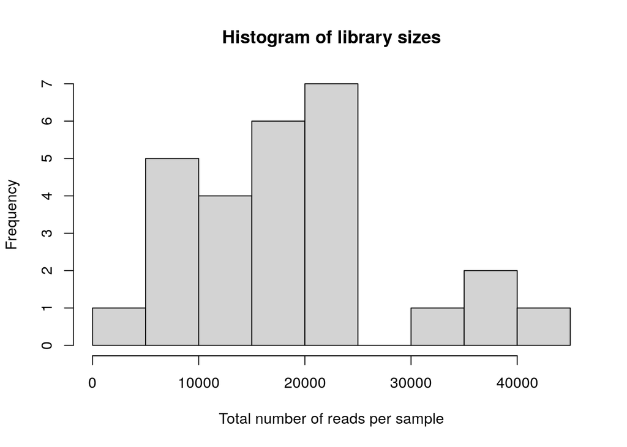

```r
tse <- addPerCellQC(tse) # adding a new column "sum" to colData, of total counts/sample.
hist(colData(tse)$sum, xlab = "Total number of reads per sample", main = "Histogram of library sizes")
```

* **Taxonomy table** Retrieve the taxonomy table and print out the first few lines of it with the R command head(). Investigate how many different phylum-level groups this phyloseq object has?

```r
head(rowData(tse))
```

```
## DataFrame with 6 rows and 6 columns
##              Kingdom          Phylum            Class              Order              Family           Genus
##          <character>     <character>      <character>        <character>         <character>     <character>
## 1726470     Bacteria   Bacteroidetes      Bacteroidia      Bacteroidales      Bacteroidaceae     Bacteroides
## 1726471     Bacteria   Bacteroidetes      Bacteroidia      Bacteroidales      Bacteroidaceae     Bacteroides
## 17264731    Bacteria   Bacteroidetes      Bacteroidia      Bacteroidales  Porphyromonadaceae Parabacteroides
## 17264726    Bacteria   Bacteroidetes      Bacteroidia      Bacteroidales      Bacteroidaceae     Bacteroides
## 1726472     Bacteria Verrucomicrobia Verrucomicrobiae Verrucomicrobiales Verrucomicrobiaceae     Akkermansia
## 17264724    Bacteria   Bacteroidetes      Bacteroidia      Bacteroidales      Bacteroidaceae     Bacteroides
```

```r
taxonomyRanks(tse) # The taxonomic ranks available
```

```
## [1] "Kingdom" "Phylum"  "Class"   "Order"   "Family"  "Genus"
```

```r
unique(rowData(tse)["Phylum"]) # phylum-level groups
```

```
## DataFrame with 5 rows and 1 column
##                    Phylum
##               <character>
## 1726470     Bacteroidetes
## 1726472   Verrucomicrobia
## 17264729   Proteobacteria
## 172647189      Firmicutes
## 17264742    Cyanobacteria
```

```r
length(unique(rowData(tse)["Phylum"])[,1]) # number of phylum-level groups
```

```
## [1] 5
```

- **Sample metadata** Retrieve sample metadata. How many patient groups this data set has? Draw a histogram of sample diversities.

```r
colData(tse) # samples metadata
```

```
## DataFrame with 27 rows and 7 columns
##      patient_status      cohort patient_status_vs_cohort sample_name       sum  detected     total
##         <character> <character>              <character> <character> <numeric> <numeric> <numeric>
## A110           ADHD    Cohort_1            ADHD_Cohort_1        A110     37394        68     37394
## A12            ADHD    Cohort_1            ADHD_Cohort_1         A12     40584        51     40584
## A15            ADHD    Cohort_1            ADHD_Cohort_1         A15     16077        68     16077
## A19            ADHD    Cohort_1            ADHD_Cohort_1         A19     39210        62     39210
## A21            ADHD    Cohort_2            ADHD_Cohort_2         A21      6351        58      6351
## ...             ...         ...                      ...         ...       ...       ...       ...
## A26         Control    Cohort_2         Control_Cohort_2         A26     20431        64     20431
## A27         Control    Cohort_2         Control_Cohort_2         A27     14636        86     14636
## A33         Control    Cohort_3         Control_Cohort_3         A33     13051        78     13051
## A35         Control    Cohort_3         Control_Cohort_3         A35     12642        62     12642
## A38         Control    Cohort_3         Control_Cohort_3         A38     15544        74     15544
```

```r
unique(colData(tse)$patient_status) # patient groups
```

```
## [1] "ADHD"    "Control"
```

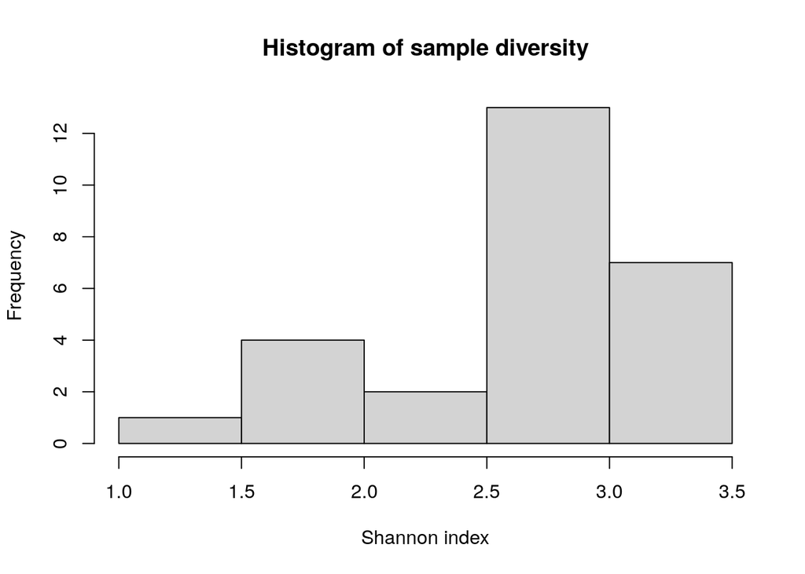

```r
# Example of sample diversity using Shannon index
tse <- mia::estimateDiversity(tse,
                             abund_values = "counts",
                             index = "shannon",
                             name = "shannon")
hist(colData(tse)$shannon, xlab = "Shannon index", main = "Histogram of sample diversity")
```

- **Subsetting** Pick a subset of the data object including only ADHD individuals from Cohort 1. How many there are?

```r
sub_cohort_1 <- tse[, colData(tse)$cohort=="Cohort_1"]
sub_cohort_1_ADHD <- sub_cohort_1[, colData(sub_cohort_1)$patient_status=="ADHD"]
colData(sub_cohort_1_ADHD)
```

```
## DataFrame with 4 rows and 8 columns
##      patient_status      cohort patient_status_vs_cohort sample_name       sum  detected     total   shannon
##         <character> <character>              <character> <character> <numeric> <numeric> <numeric> <numeric>
## A110           ADHD    Cohort_1            ADHD_Cohort_1        A110     37394        68     37394   1.76541
## A12            ADHD    Cohort_1            ADHD_Cohort_1         A12     40584        51     40584   2.71644
## A15            ADHD    Cohort_1            ADHD_Cohort_1         A15     16077        68     16077   3.17810
## A19            ADHD    Cohort_1            ADHD_Cohort_1         A19     39210        62     39210   2.89199
```

- **Transformations** The data contains read counts. We can convert these into relative abundances and other formats. Compare abundance of a given taxonomic group using the example data before and after the compositionality transformation (with a cross-plot, for instance). You can also compare the results to CLR-transformed data (see e.g. [Gloor et al. 2017](https://www.frontiersin.org/articles/10.3389/fmicb.2017.02224/full))

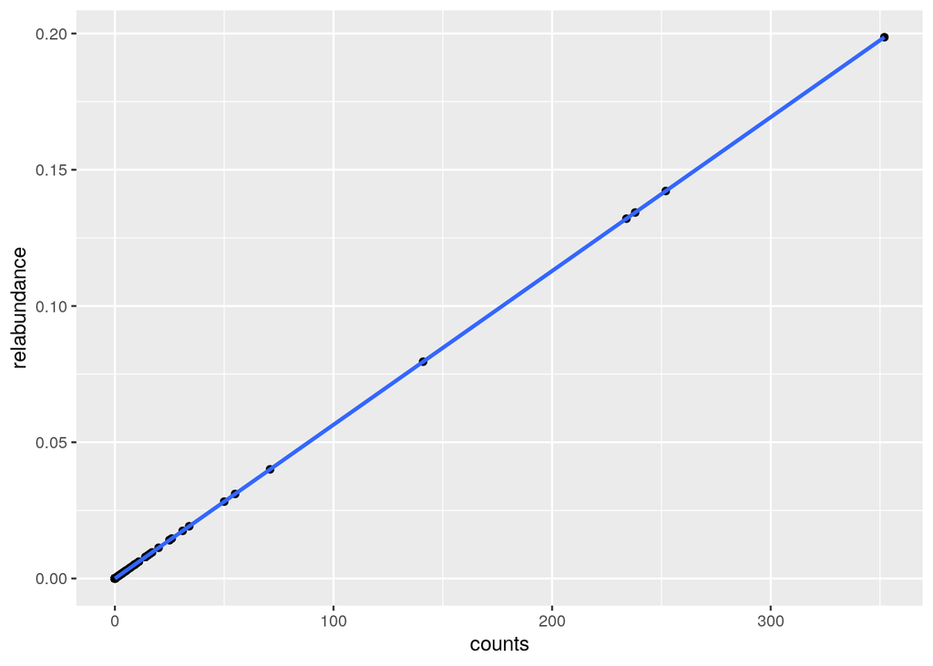

```r
tse <- transformCounts(tse, method = "relabundance")
tse <- transformCounts(tse, method = "clr", abund_values = "counts",pseudocount = 1)
# Lets compare with taxa: A29
taxa <- "A29"
df <- as.data.frame(list(
                          counts=assays(tse)$counts[,taxa],
                          relabundance=assays(tse)$relabundance[,taxa],
                          clr=assays(tse)$clr[,taxa])
                        )
ggplot(df, aes(x=counts,y=relabundance))+
  geom_point()+
  geom_smooth()
```

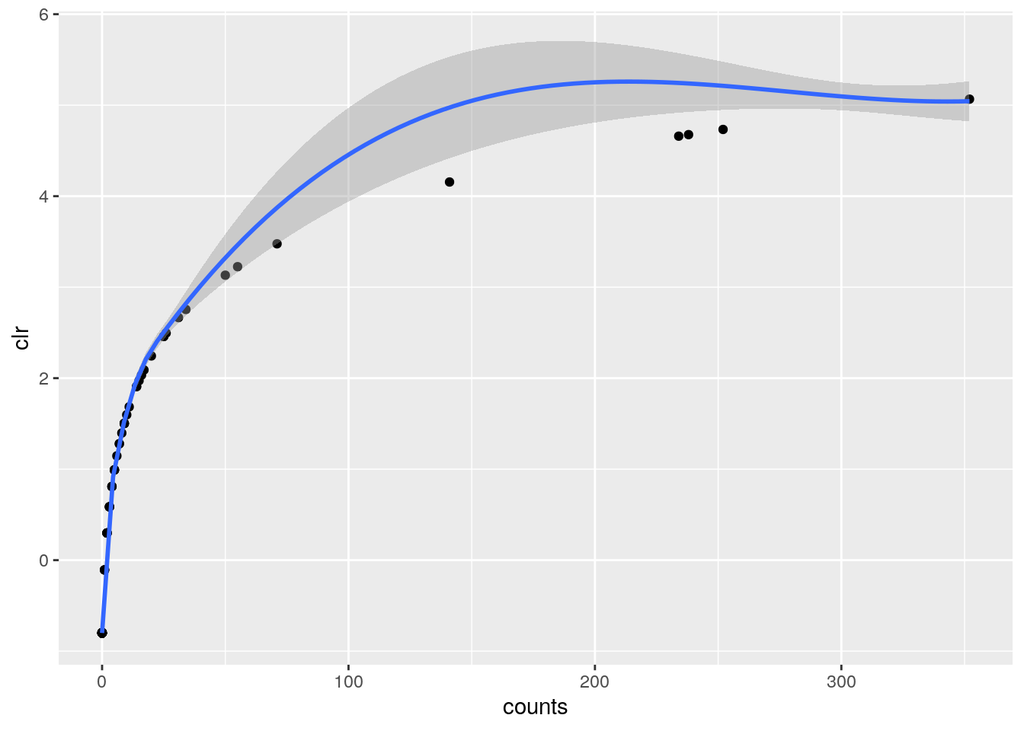

```r
ggplot(df, aes(x=counts,y=clr))+
  geom_point()+
  geom_smooth()
```

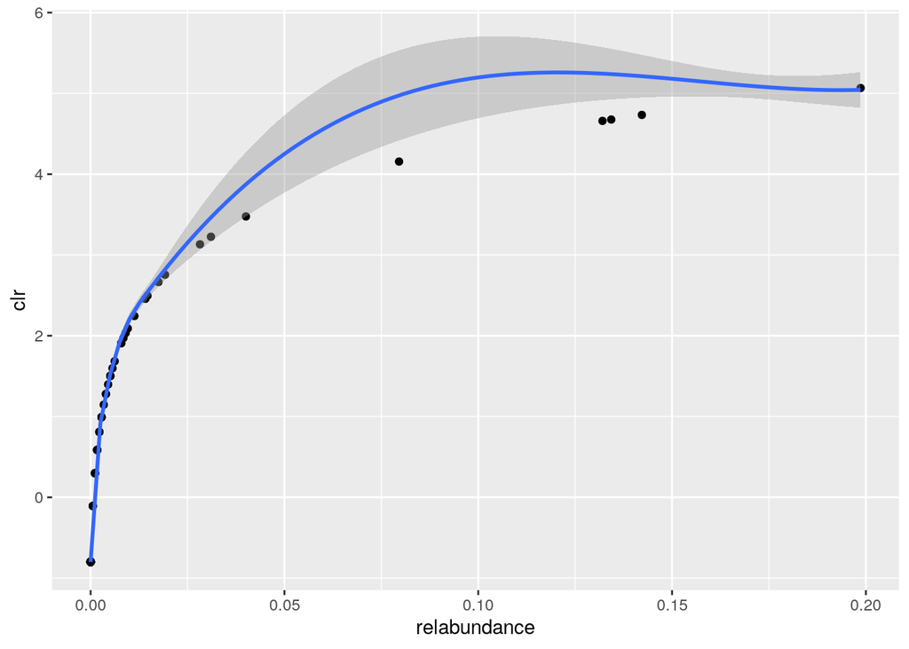

```r
ggplot(df, aes(x=relabundance,y=clr))+
  geom_point()+
  geom_smooth()
```

* **Visual exploration** Visualize the population distribution of abundances for certain taxonomic groups. Do the same for CLR-transformed abundances.

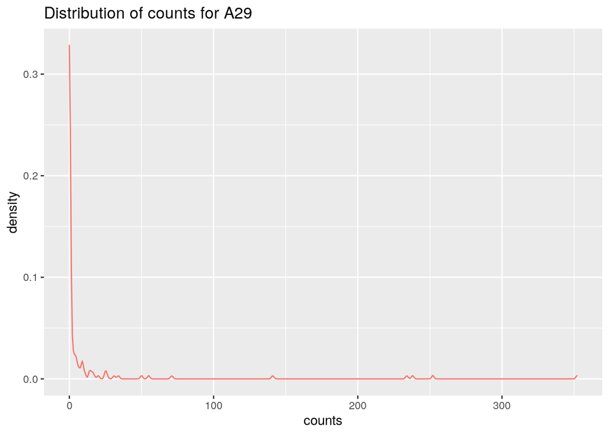

```r
# Same taxa used as earlier
ggplot(df, aes(x=counts,colour="blue")) +
    geom_density(alpha=.2)+
  theme(legend.position = "none")+
  labs(title =paste("Distribution of counts for",taxa, collapse = ": "))
```

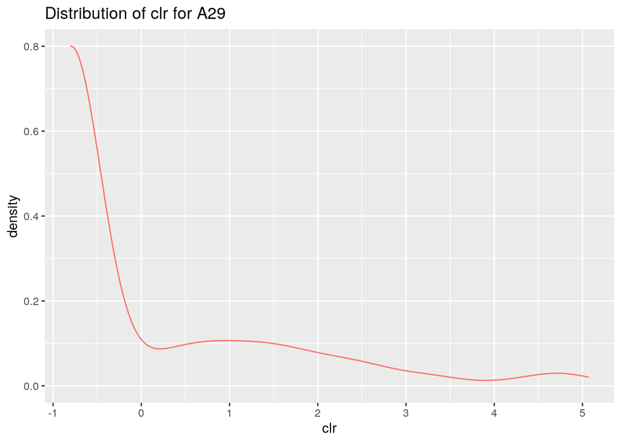

```r
ggplot(df, aes(x=clr,colour="red")) +
    geom_density(alpha=.2)+
  theme(legend.position = "none")+
  labs(title =paste("Distribution of clr for",taxa, collapse = ": "))
```